# Appendix B: Data manipulation, RoB visualization, and PRIMED workflow

### Across outcome subgroups

```r
# Multi-arms studies
multi_arm_studies_reint <-
  reintegration_dat |>
  filter(trt_id > 1) |>
  reframe(study = unique(study))


# Multi-time-points studies
follow_up_studies_reint <-
  reintegration_dat |>
  summarise(
    time_points = length(unique(time_after_end_intervention_weeks)),
    .by = c(study, trt_id, ctr_id)
  ) |>
  filter(time_points > 1)

# Preregistered studies
prereg_studies_reint <-
  reintegration_dat |>
  summarise(
    prereg_chr = unique(prereg_chr),
    n_es = n(),
    .by = study
  ) |>
  summarise(
    N_studies = n_distinct(study),
    N_es = sum(n_es),
    .by = prereg_chr
  )

study_sample_sizes_reint <-
  reintegration_dat |>
  group_by(study, trt_id, ctr_id) |>
  summarise(
    effects = n(),
    participants = max(N_total)
  ) |>
  summarise(
    effects = sum(effects),
    participants = mean(participants),
    ctl_comparisons = n(),
    ctl_arms = paste(ctr_id, collapse = "; ")
  ) |>
  group_by(study, ctl_arms) |>
  summarise(
    effects = sum(effects),
    participants = mean(participants * (1 + ctl_comparisons * (n() - 1) / 2)),
    trt_comparisons = n(),
    trt_arms = paste(trt_id, collapse = "; "),
    ctl_comparisons = mean(ctl_comparisons)
  ) |>
  summarise(
    effects = sum(effects),
    participants = sum(participants),
    trt_comparisons = mean(trt_comparisons),
    ctl_comparisons = sum(ctl_comparisons)
  )

sample_size_summary_reint <-
  study_sample_sizes_reint |>
  summarise(
    studies = n(),
    studies_multiple_tx = sum(trt_comparisons > 1),
    studies_multiple_ctl = sum(ctl_comparisons > 1),
    n_effects = sum(effects),
    mean_effects = mean(effects),
    min_effects = min(effects),
    median_effects = median(effects),
    max_effects = max(effects),
    participants = round(sum(participants))
  ) |>
  mutate(prereg = prereg_studies_reint$N_studies[1])

n_studies_reint <- sample_size_summary_reint$studies
```

```r
kable(
  sample_size_summary_reint,
  col.names = c(
    studies = "Studies",
    studies_multiple_tx = "Multi-treatment studies",
    studies_multiple_ctl = "Multi-control studies",
    n_effects = "Effects",
    mean_effects = "Mean",
    min_effects = "Minimum",
    median_effects = "Median",
    max_effects = "Maximum",
    participants = "Participants",
    prereg = "Preregistered studies"
  ),
  digits = 1
) |>
  kable_styling(bootstrap_options = c("striped", "condensed"),
                full_width = FALSE)
```

Table 4: Data structure for the reintegrational data.

| Studies | Multi-treatment studies | Multi-control studies | Effects | Mean | Minimum | Median | Maximum | Participants | Preregistered studies |
| --- | --- | --- | --- | --- | --- | --- | --- | --- | --- |
| 46 | 3 | 0 | 205 | 4.5 | 1 | 3 | 28 | 5406 | 22 |

```r
# Multi-arms studies
multi_arm_studies_mental <-
  mental_health_dat |>
  filter(trt_id > 1) |>
  reframe(study = unique(study))


# Multi-time-points studies
follow_up_studies_mental <-
  mental_health_dat |>
  summarise(
    time_points = length(unique(time_after_end_intervention_weeks)),
    .by = c(study, trt_id, ctr_id)
  ) |>
  filter(time_points > 1)

# Preregistered studies
prereg_studies_mental <-
  mental_health_dat |>
  summarise(
    prereg_chr = unique(prereg_chr),
    n_es = n(),
    .by = study
  ) |>
  summarise(
    N_studies = n_distinct(study),
    N_es = sum(n_es),
    .by = prereg_chr
  )

study_sample_sizes_mental <-
  mental_health_dat |>
  group_by(study, trt_id, ctr_id) |>
  summarise(
    effects = n(),
    participants = max(N_total)
  ) |>
  summarise(
    effects = sum(effects),
    participants = mean(participants),
    ctl_comparisons = n(),
    ctl_arms = paste(ctr_id, collapse = "; ")
  ) |>
  group_by(study, ctl_arms) |>
  summarise(
    effects = sum(effects),
    participants = mean(participants * (1 + ctl_comparisons * (n() - 1) / 2)),
    trt_comparisons = n(),
    trt_arms = paste(trt_id, collapse = "; "),
    ctl_comparisons = mean(ctl_comparisons)
  ) |>
  summarise(
    effects = sum(effects),
    participants = sum(participants),
    trt_comparisons = mean(trt_comparisons),
    ctl_comparisons = sum(ctl_comparisons)
  )

sample_size_summary_mental <-
  study_sample_sizes_mental |>
  summarise(
    studies = n(),
    studies_multiple_tx = sum(trt_comparisons > 1),
    studies_multiple_ctl = sum(ctl_comparisons > 1),
    n_effects = sum(effects),
    mean_effects = mean(effects),
    min_effects = min(effects),
    median_effects = median(effects),
    max_effects = max(effects),
    participants = round(sum(participants))
  ) |>
  mutate(prereg = prereg_studies_mental$N_studies[1])

n_studies_mental <- sample_size_summary_mental$studies
```

```r
kable(
  sample_size_summary_mental,
  col.names = c(
    studies = "Studies",
    studies_multiple_tx = "Multi-treatment studies",
    studies_multiple_ctl = "Multi-control studies",
    n_effects = "Effects",
    mean_effects = "Mean",
    min_effects = "Minimum",
    median_effects = "Median",
    max_effects = "Maximum",
    participants = "Participants",
    prereg = "Preregistered studies"
  ),
  digits = 1
) |>
  kable_styling(bootstrap_options = c("striped", "condensed"),
                full_width = FALSE)
```

Table 5: Data structure for the mental health data.

| Studies | Multi-treatment studies | Multi-control studies | Effects | Mean | Minimum | Median | Maximum | Participants | Preregistered studies |
| --- | --- | --- | --- | --- | --- | --- | --- | --- | --- |
| 42 | 3 | 0 | 144 | 3.4 | 1 | 2 | 18 | 4679 | 20 |

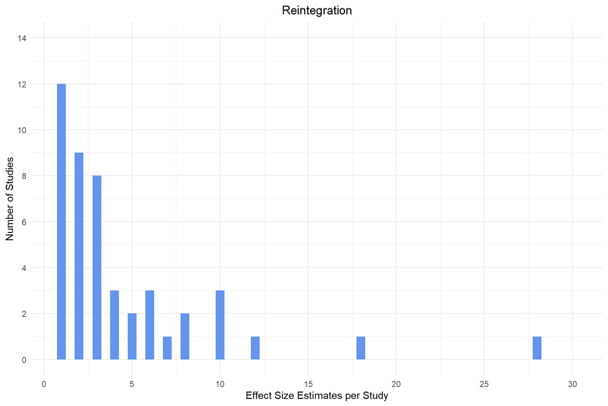

Figure 33: Distribution of number of effects per study for reintegrational outcomes.

```r
reintegration_dat |>
  summarise(
    es_count = n(),
    .by = study
  ) |>
  arrange(es_count) |>
  ggplot(aes(x = es_count)) +
  geom_histogram(binwidth = 0.5, fill = "cornflowerblue") +
  scale_x_continuous(breaks = seq(0, 30, by = 5)) +
  scale_y_continuous(breaks = seq(0, 14, 2), limits = c(0, 14)) +
  theme_minimal() +
  theme(plot.title = element_text(hjust = 0.5)) +
  labs(x = "Effect Size Estimates per Study", y = "Number of Studies", title = "Reintegration") +
  expand_limits(x = 30)
```

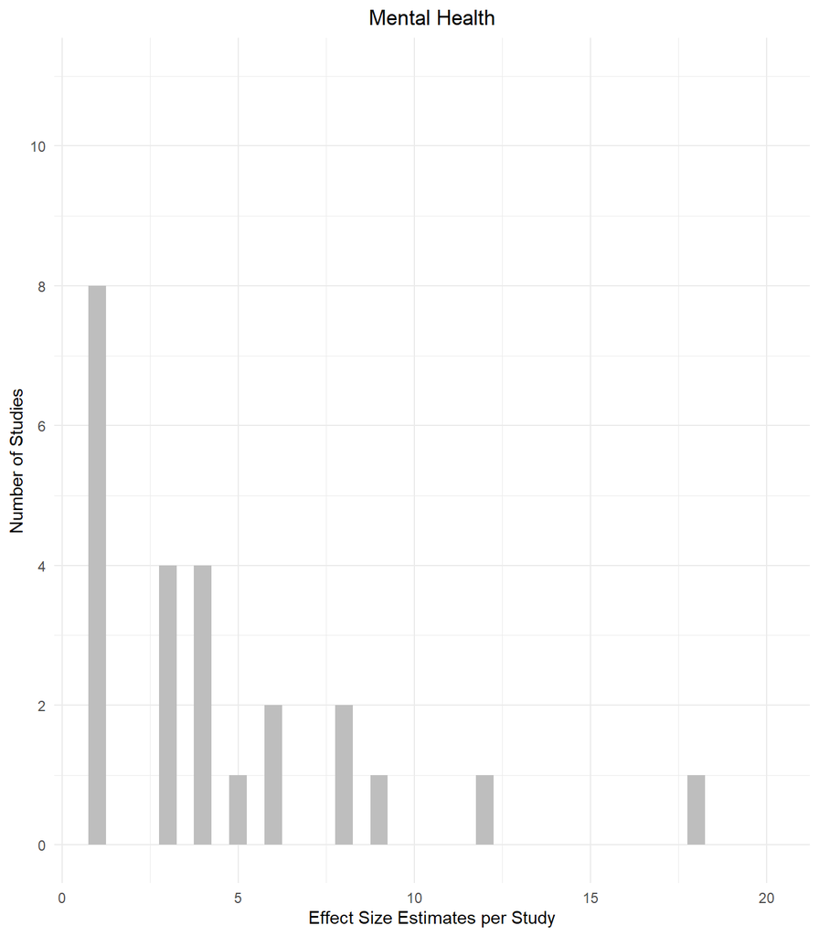

Figure 34: Distribution of number of effects per study for mental health outcomes.

```r
mental_health_dat |>
  summarise(
    es_count = n(),
    .by = study
  ) |>
  arrange(es_count) |>
  ggplot(aes(x = es_count)) +
  geom_histogram(binwidth = 0.5, fill = "gray") +
  scale_x_continuous(breaks = seq(0, 20, by = 5)) +
  scale_y_continuous(breaks = seq(0, 10, 2), limits = c(0, 11)) +
  theme_minimal() +
  theme(plot.title = element_text(hjust = 0.5)) +
  labs(x = "Effect Size Estimates per Study", y = "Number of Studies", title = "Mental Health") +
  expand_limits(x = 20)
```

## Data structure by outcome constructs

```r
label_cat_hist_ridge <- function(data, n_es, variable, label_map, level_order) {
  require(dplyr)
  require(rlang)
  require(tidyr)
  require(ggplot2)
  require(forcats)

  n_es_exp <- enquo(n_es)
  var_exp <- enquo(variable)

  data <- data |>
    mutate(
      !!var_exp := fct_recode(!!var_exp, !!!label_map),
      !!var_exp := fct_relevel(!!var_exp, !!!level_order),
      !!var_exp := fct_rev(!!var_exp)
    )

  ggplot(data, aes(
    x = !!n_es_exp,
    y = !!var_exp,
    fill = !!var_exp
  )) +
    geom_density_ridges(
      alpha = 1,
      stat = "binline",
      bins = 30,
      scale = 0.7,
      linewidth = 0.1,
      draw_baseline = FALSE
    ) +
    theme_minimal() +
    labs(y = "", x = "Effect Size Estimates per Study") +
    theme(legend.position = "none")
}
```

The following plot shows the effect size estimates distribution within each outcome construct.

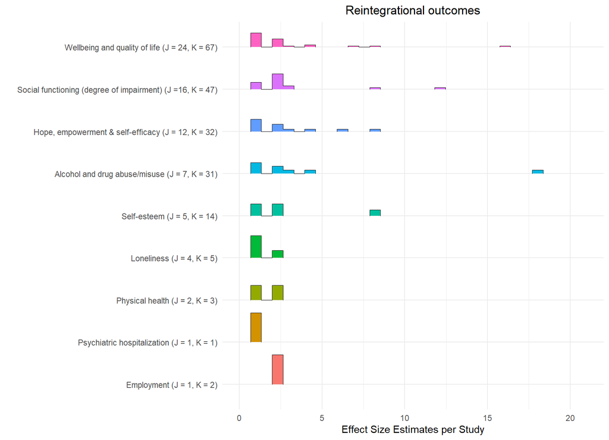

Figure 35: Distribution of effect size estimates, by reintegrational outcome constructs.

```r
n_es_by_construct <-
  gb_dat |>
  filter(str_detect(outcome_construct, "Re")) |>
  summarise(effects = n(), .by = c(study, analysis_plan)) |>
  mutate(J = n(), .by = c(analysis_plan)) |>
  arrange(desc(J))

# Used to construct out_label
#label_dat <-
#  n_es_by_construct |>
#  summarise(J = n(), N_es = sum(effects), .by = analysis_plan)


out_label <- c(
  "Wellbeing and quality of life (J = 24, K = 67)" = "Wellbeing and quality of life",
  "Social functioning (degree of impairment) (J =16, K = 47)" = "Social functioning (degree of impairment)",
  "Hope, empowerment & self-efficacy (J = 12, K = 32)" = "Hope, empowerment & self-efficacy",
  "Alcohol and drug abuse/misuse (J = 7, K = 31)" = "Alcohol and drug abuse/misuse",
  "Self-esteem (J = 5, K = 14)" = "Self-esteem",
  "Loneliness (J = 4, K = 5)" = "Loneliness",
  "Physical health (J = 2, K = 3)" = "Physical health",
  "Psychiatric hospitalization (J = 1, K = 1)" = "Psychiatric hospitalization",
  "Employment (J = 1, K = 2)" = "Employment"
)

out_level <- c(
 "Wellbeing and quality of life (J = 24, K = 67)",
  "Social functioning (degree of impairment) (J =16, K = 47)",
  "Hope, empowerment & self-efficacy (J = 12, K = 32)",
  "Alcohol and drug abuse/misuse (J = 7, K = 31)",
  "Self-esteem (J = 5, K = 14)",
  "Loneliness (J = 4, K = 5)",
  "Physical health (J = 2, K = 3)",
  "Psychiatric hospitalization (J = 1, K = 1)",
  "Employment (J = 1, K = 2)"
)

label_cat_hist_ridge(
  data = n_es_by_construct,
  n_es = effects,
  variable = analysis_plan,
  label_map = out_label,
  level_order = out_level
) +
  expand_limits(x = 20) +
  labs(title = "Reintegrational outcomes") +
  theme(plot.title = element_text(hjust = 0.5))
```

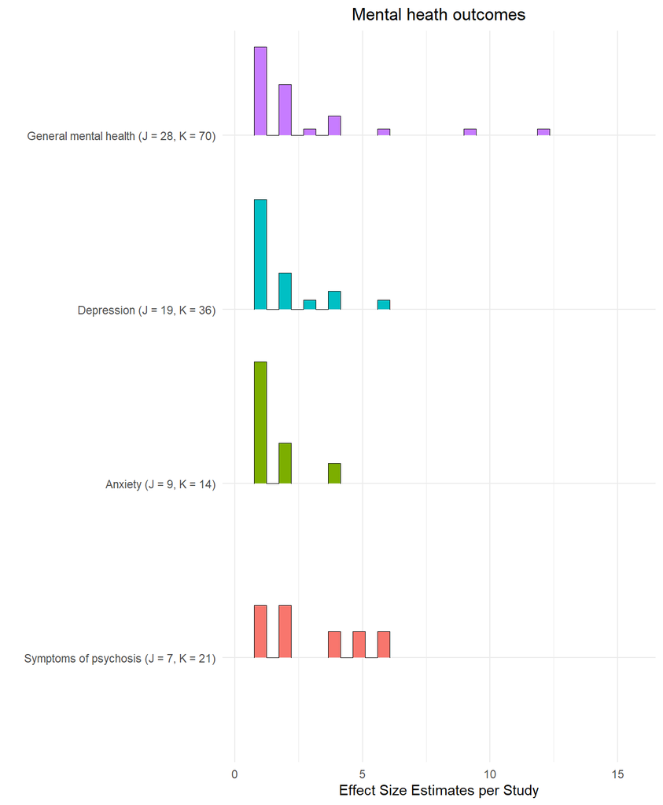

Figure 36: Distribution of effect size estimates, by mental health outcome constructs.

```r
n_es_by_construct_mental <-
  gb_dat |>
  filter(str_detect(outcome_construct, "Men")) |>
  summarise(effects = n(), .by = c(study, analysis_plan)) |>
  mutate(J = n(), .by = c(analysis_plan)) |>
  arrange(desc(J))

# Used to construct out_label_mental
#label_dat_mental <-
#  n_es_by_construct_mental |>
#  summarise(J = n(), N_es = sum(effects), .by = analysis_plan)

out_label_mental <- c(
  "General mental health (J = 28, K = 70)" = "General mental health",
  "Depression (J = 19, K = 36)" = "Depression",
  "Anxiety (J = 9, K = 14)" = "Anxiety",
  "Symptoms of psychosis (J = 7, K = 21)" = "Symptoms of psychosis"
)

out_level_mental <- c(
  "General mental health (J = 28, K = 70)",
  "Depression (J = 19, K = 36)",
  "Anxiety (J = 9, K = 14)",
  "Symptoms of psychosis (J = 7, K = 21)"
)

label_cat_hist_ridge(
  data = n_es_by_construct_mental,
  n_es = effects,
  variable = analysis_plan,
  label_map = out_label_mental,
  level_order = out_level_mental
) +
  expand_limits(x = 15) +
  labs(title = "Mental heath outcomes") +
  theme(plot.title = element_text(hjust = 0.5))
```

## Primary study sample size

### Total sample sizes

```r
# Used when describing the treatment group sample sizes
N_t_stud_trtid <-
  reintegration_dat |>
  reframe(N_treat = max(N_t), .by = c(study, trt_id))

N_t_total <-
  N_t_stud_trtid |>
  summarise(N_t_total = sum(N_treat), .by = study)

N_c_total <-
  reintegration_dat |>
  summarise(N_c_total = max(N_c), .by = study)

N_total_dat <-
  left_join(N_t_total, N_c_total, by = join_by(study)) |>
  mutate(N_total = N_t_total + N_c_total)


primary_sample_size_descriptive <-
  N_total_dat$N_total |>
  skim() |>
  select(-skim_type, -skim_variable, -n_missing, -complete_rate, -numeric.hist) |>
  rename_at(vars(starts_with("numeric.")), ~ str_remove(., "numeric\\."))

primary_sample_size_descriptive |>
  knitr::kable(
    digits = 2,
    booktabs = TRUE
  ) |>
  kable_styling(bootstrap_options = c("striped","condensed"), full_width = FALSE)
```

Table 6: Distribution of primary study sample sizes at post test for reintegrational outcomes

| mean | sd | p0 | p25 | p50 | p75 | p100 |
| --- | --- | --- | --- | --- | --- | --- |
| 117.52 | 127.19 | 16 | 40.25 | 60 | 133.25 | 631 |

```r
# Used when describing the treatment group sample sizes
N_t_stud_trtid_mental <-
  mental_health_dat |>
  reframe(N_treat = max(N_t), .by = c(study, trt_id))

N_t_total_mental <-
  N_t_stud_trtid_mental |>
  summarise(N_t_total = sum(N_treat), .by = study)

N_c_total_mental <-
  mental_health_dat |>
  summarise(N_c_total = max(N_c), .by = study)

N_total_dat_mental <-
  left_join(N_t_total_mental, N_c_total_mental, by = join_by(study)) |>
  mutate(N_total = N_t_total + N_c_total)


primary_sample_size_descriptive_mental <-
  N_total_dat_mental$N_total |>
  skim() |>
  select(-skim_type, -skim_variable, -n_missing, -complete_rate, -numeric.hist) |>
  rename_at(vars(starts_with("numeric.")), ~ str_remove(., "numeric\\."))

primary_sample_size_descriptive_mental |>
  knitr::kable(
    digits = 2,
    booktabs = TRUE
  ) |>
  kable_styling(bootstrap_options = c("striped","condensed"), full_width = FALSE)
```

Table 7: Distribution of primary study sample sizes at post test for mental health outcomes

| mean | sd | p0 | p25 | p50 | p75 | p100 |
| --- | --- | --- | --- | --- | --- | --- |
| 111.4 | 124.97 | 16 | 39.25 | 60.5 | 126 | 631 |

The following plot displays the distribution of study sample sizes at post-test.

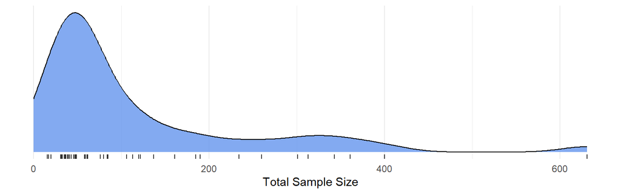

Figure 37: Distribution of primary study sample sizes at post test for reintegrational outcomes.

```r
study_sizes_plot_reint <-
  ggplot(N_total_dat, aes(N_total)) +
  geom_density(fill = "cornflowerblue", alpha = 0.8) +
  geom_blank(aes(x = 0, y = 0)) +
  geom_rug(alpha = 0.8) +
  scale_y_continuous(NULL, breaks = NULL) +
  theme_minimal() +
  labs(x = "Total Sample Size", y = "")
study_sizes_plot_reint
```

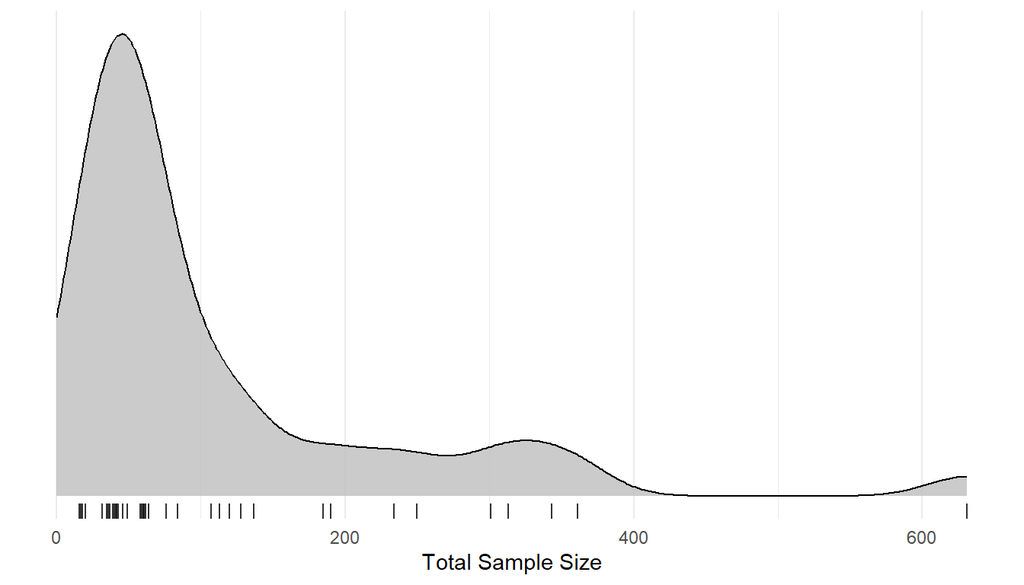

Figure 38: Distribution of primary study sample sizes at post test for mental health outcomes.

```r
study_sizes_plot_mental <-
  ggplot(N_total_dat_mental, aes(N_total)) +
  geom_density(fill = "gray", alpha = 0.8) +
  geom_blank(aes(x = 0, y = 0)) +
  geom_rug(alpha = 0.8) +
  scale_y_continuous(NULL, breaks = NULL) +
  theme_minimal() +
  labs(x = "Total Sample Size", y = "")
study_sizes_plot_mental
```

### Total EFFECTIVE sample sizes

```r
# Used when describing the treatment group sample sizes
N_t_stud_trtid_ESS <-
  reintegration_dat |>
  reframe(N_treat_ESS = max(ESS_t), .by = c(study, trt_id))

N_t_total_ESS <-
  N_t_stud_trtid_ESS |>
  summarise(N_t_total_ESS = sum(N_treat_ESS), .by = study)

N_c_total_ESS <-
  reintegration_dat |>
  summarise(N_c_total_ESS = max(ESS_c), .by = study)

N_total_ESS_dat <-
  left_join(N_t_total_ESS, N_c_total_ESS, by = join_by(study)) |>
  mutate(N_total_ESS = N_t_total_ESS + N_c_total_ESS)


primary_ESS_sample_size_descriptive <-
  N_total_ESS_dat$N_total_ESS |>
  skim() |>
  select(-skim_type, -skim_variable, -n_missing, -complete_rate, -numeric.hist) |>
  rename_at(vars(starts_with("numeric.")), ~ str_remove(., "numeric\\."))

primary_ESS_sample_size_descriptive |>
  knitr::kable(
    digits = 2,
    booktabs = TRUE
  ) |>
  kable_styling(bootstrap_options = c("striped","condensed"), full_width = FALSE)
```

Table 8: Distribution of primary study effective sample sizes at post test for reintegrational outcomes

| mean | sd | p0 | p25 | p50 | p75 | p100 |
| --- | --- | --- | --- | --- | --- | --- |
| 69.52 | 73.29 | 10 | 23.25 | 37.5 | 84.5 | 351 |

```r
# Used when describing the treatment group sample sizes
N_t_stud_trtid_mental_ESS <-
  mental_health_dat |>
  reframe(N_treat_ESS = max(ESS_t), .by = c(study, trt_id))

N_t_total_mental_ESS <-
  N_t_stud_trtid_mental_ESS |>
  summarise(N_t_total_ESS = sum(N_treat_ESS), .by = study)

N_c_total_mental_ESS <-
  mental_health_dat |>
  summarise(N_c_total_ESS = max(ESS_c), .by = study)

N_total_ESS_dat_mental <-
  left_join(N_t_total_mental_ESS, N_c_total_mental_ESS, by = join_by(study)) |>
  mutate(N_total_ESS = N_t_total_ESS + N_c_total_ESS)


primary_ESS_sample_size_descriptive_mental <-
  N_total_ESS_dat_mental$N_total_ESS |>
  skim() |>
  select(-skim_type, -skim_variable, -n_missing, -complete_rate, -numeric.hist) |>
  rename_at(vars(starts_with("numeric.")), ~ str_remove(., "numeric\\."))

primary_ESS_sample_size_descriptive_mental |>
  knitr::kable(
    digits = 2,
    booktabs = TRUE
  ) |>
  kable_styling(bootstrap_options = c("striped","condensed"), full_width = FALSE)
```

Table 9: Distribution of primary study effective sample sizes at post test for mental health outcomes

| mean | sd | p0 | p25 | p50 | p75 | p100 |
| --- | --- | --- | --- | --- | --- | --- |
| 66.9 | 71.46 | 10 | 23 | 38 | 80 | 351 |

The following plot displays the distribution of the effective study sample sizes at post-test.

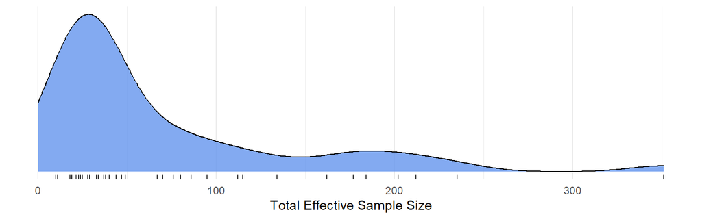

Figure 39: Distribution of primary effective study sample sizes at post test for reintegrational outcomes.

```r
study_sizes_plot_reint_ESS <-
  ggplot(N_total_ESS_dat, aes(N_total_ESS)) +
  geom_density(fill = "cornflowerblue", alpha = 0.8) +
  geom_blank(aes(x = 0, y = 0)) +
  geom_rug(alpha = 0.8) +
  scale_y_continuous(NULL, breaks = NULL) +
  theme_minimal() +
  labs(x = "Total Effective Sample Size", y = "")
study_sizes_plot_reint_ESS
```

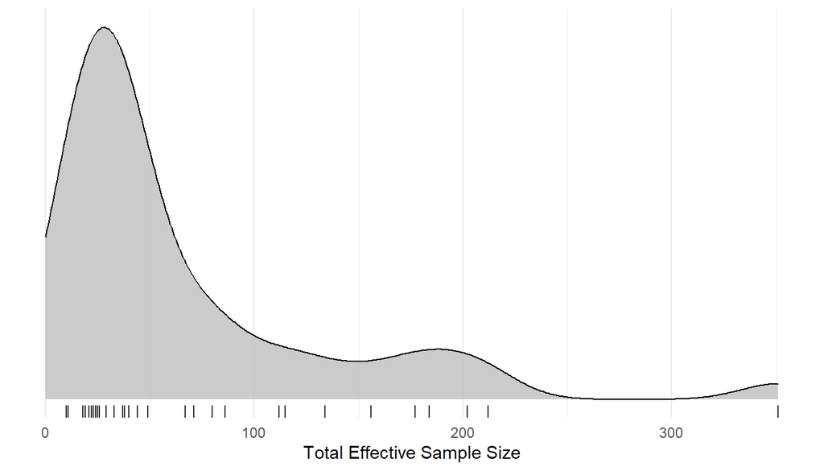

Figure 40: Distribution of primary effective study sample sizes at post test for mental health outcomes.

```r
study_sizes_plot_mental_ESS <-
  ggplot(N_total_ESS_dat_mental, aes(N_total_ESS)) +
  geom_density(fill = "gray", alpha = 0.8) +
  geom_blank(aes(x = 0, y = 0)) +
  geom_rug(alpha = 0.8) +
  scale_y_continuous(NULL, breaks = NULL) +
  theme_minimal() +
  labs(x = "Total Effective Sample Size", y = "")
study_sizes_plot_mental_ESS
```

### Treatment group

```r
treatment_sample_size_descriptive <-
  N_t_stud_trtid$N_treat |>
  skim() |>
  select(-skim_type, -skim_variable, -n_missing, -complete_rate, -numeric.hist) |>
  rename_at(vars(starts_with("numeric.")), ~ str_remove(., "numeric\\."))

treatment_sample_size_descriptive |>
  knitr::kable(
    digits = 2,
    booktabs = TRUE
  ) |>
  kable_styling(bootstrap_options = c("striped","condensed"), full_width = FALSE)
```

Table 10: Distribution of treatment sample sizes at post test for reintegrational outcomes

| mean | sd | p0 | p25 | p50 | p75 | p100 |
| --- | --- | --- | --- | --- | --- | --- |
| 59.78 | 60.18 | 7 | 22 | 32 | 90 | 315 |

```r
treatment_sample_size_descriptive_mental <-
  N_t_stud_trtid_mental$N_treat |>
  skim() |>
  select(-skim_type, -skim_variable, -n_missing, -complete_rate, -numeric.hist) |>
  rename_at(vars(starts_with("numeric.")), ~ str_remove(., "numeric\\."))

treatment_sample_size_descriptive_mental |>
  knitr::kable(
    digits = 2,
    booktabs = TRUE
  ) |>
  kable_styling(bootstrap_options = c("striped","condensed"), full_width = FALSE)
```

Table 11: Distribution of treatment sample sizes at post test for mental health outcomes

| mean | sd | p0 | p25 | p50 | p75 | p100 |
| --- | --- | --- | --- | --- | --- | --- |
| 56.67 | 58.91 | 7 | 21 | 29 | 70 | 315 |

The following plot displays the distribution of treatment sample sizes at post-test.

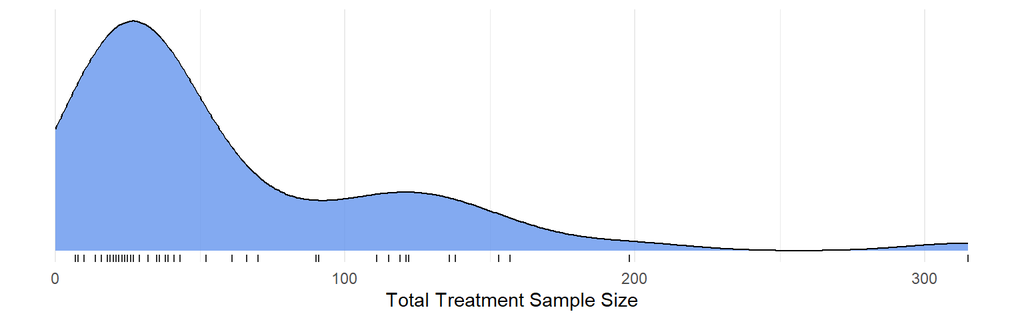

Figure 41: Distribution of treatment sample sizes at post test for reintegrational outcomes.

```r
treatment_sizes_plot_reint <-
  ggplot(N_t_stud_trtid, aes(N_treat)) +
  geom_density(fill = "cornflowerblue", alpha = 0.8) +
  geom_blank(aes(x = 0, y = 0)) +
  geom_rug(alpha = 0.8) +
  scale_y_continuous(NULL, breaks = NULL) +
  theme_minimal() +
  labs(x = "Total Treatment Sample Size", y = "")
treatment_sizes_plot_reint
```

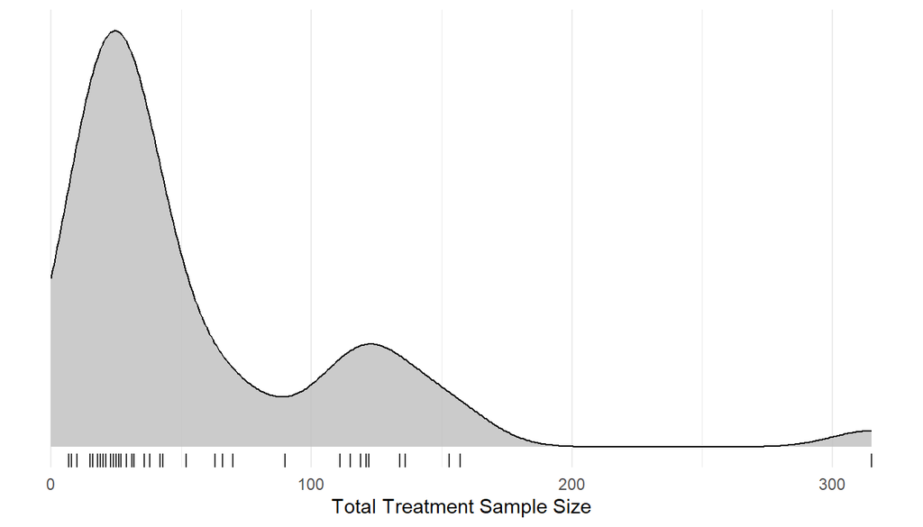

Figure 42: Distribution of treatment sample sizes at post test for mental health outcomes.

```r
treatment_sizes_plot_mental <-
  ggplot(N_t_stud_trtid_mental, aes(N_treat)) +
  geom_density(fill = "gray", alpha = 0.8) +
  geom_blank(aes(x = 0, y = 0)) +
  geom_rug(alpha = 0.8) +
  scale_y_continuous(NULL, breaks = NULL) +
  theme_minimal() +
  labs(x = "Total Treatment Sample Size", y = "")
treatment_sizes_plot_mental
```

### Control group

```r
control_sample_size_descriptive <-
  N_total_dat$N_c_total |>
  skim() |>
  select(-skim_type, -skim_variable, -n_missing, -complete_rate, -numeric.hist) |>
  rename_at(vars(starts_with("numeric.")), ~ str_remove(., "numeric\\."))

control_sample_size_descriptive |>
  knitr::kable(
    digits = 2,
    booktabs = TRUE
  ) |>
  kable_styling(bootstrap_options = c("striped","condensed"), full_width = FALSE)
```

Table 12: Distribution of control group sample sizes at post test for reintegrational outcomes

| mean | sd | p0 | p25 | p50 | p75 | p100 |
| --- | --- | --- | --- | --- | --- | --- |
| 53.85 | 60.21 | 9 | 18.25 | 29.5 | 62.5 | 316 |

```r
control_sample_size_descriptive_mental <-
  N_total_dat_mental$N_c_total |>
  skim() |>
  select(-skim_type, -skim_variable, -n_missing, -complete_rate, -numeric.hist) |>
  rename_at(vars(starts_with("numeric.")), ~ str_remove(., "numeric\\."))

control_sample_size_descriptive_mental |>
  knitr::kable(
    digits = 2,
    booktabs = TRUE
  ) |>
  kable_styling(bootstrap_options = c("striped","condensed"), full_width = FALSE)
```

Table 13: Distribution of control group sample sizes at post test for mental health outcomes

| mean | sd | p0 | p25 | p50 | p75 | p100 |
| --- | --- | --- | --- | --- | --- | --- |
| 50.69 | 58.27 | 9 | 17.75 | 29 | 62.5 | 316 |

The following plot displays the distribution of control sample sizes at post-test.

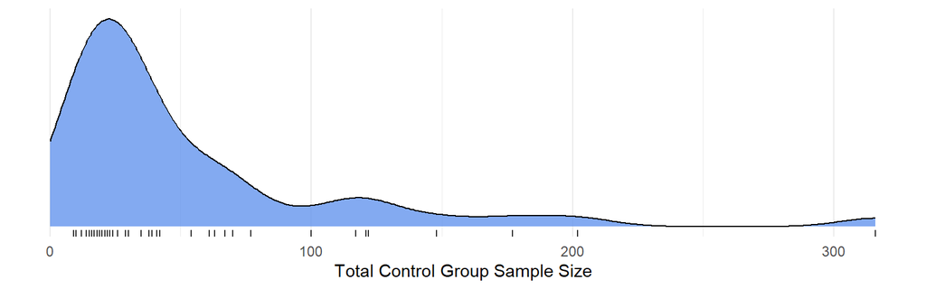

Figure 43: Distribution of control group sample sizes at post test for reintegrational outcomes.

```r
control_sizes_plot_reint <-
  ggplot(N_total_dat, aes(N_c_total)) +
  geom_density(fill = "cornflowerblue", alpha = 0.8) +
  geom_blank(aes(x = 0, y = 0)) +
  geom_rug(alpha = 0.8) +
  scale_y_continuous(NULL, breaks = NULL) +
  theme_minimal() +
  labs(x = "Total Control Group Sample Size", y = "")
control_sizes_plot_reint
```

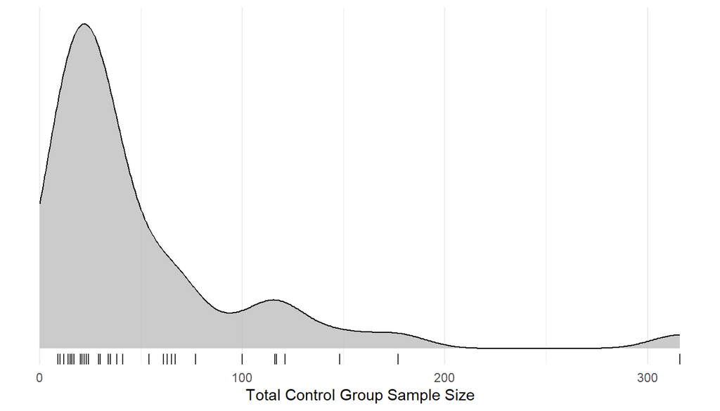

Figure 44: Distribution of control group sample sizes at post test for mental health outcomes.

```r
control_sizes_plot_mental <-
  ggplot(N_total_dat_mental, aes(N_c_total)) +
  geom_density(fill = "gray", alpha = 0.8) +
  geom_blank(aes(x = 0, y = 0)) +
  geom_rug(alpha = 0.8) +
  scale_y_continuous(NULL, breaks = NULL) +
  theme_minimal() +
  labs(x = "Total Control Group Sample Size", y = "")
control_sizes_plot_mental
```

## Study sample sizes versus number of effect size estimates per study

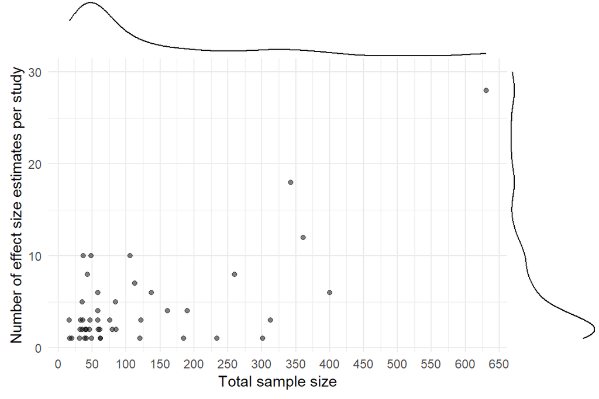

Figure 45: Study sample sizes versus number of effect size estimates for reintegrational outcomes

```r
plot <-
  reintegration_dat |>
  summarise(effects = n(), .by = study) |>
  left_join(N_total_dat, by = join_by(study)) |>
  relocate(effects, .after = N_total) |>
  ggplot(aes(x = N_total, y = effects)) +
  geom_point(alpha = 0.5) +
  scale_x_continuous(breaks = seq(0, 650, by = 50)) +
  guides(size = "none") +
  theme_minimal() +
  theme(
    legend.position = "inside",
    legend.position.inside = c(0.9, 0.05),
    legend.justification = c(1, 0),
    legend.background = element_blank()
  ) +
  labs(x = "Total sample size", y = "Number of effect size estimates per study", color = "") +
  expand_limits(y = 30)

ggMarginal(plot, type = "density")
```

# Moderators

```r
cat_dat_cross <- function(variable, study_id, data) {

  require(dplyr)
  require(rlang)
  require(tidyr)

  var_exp <- enquo(variable)
  study_id_exp <- enquo(study_id)
  study_id_name <- as_name(study_id_exp)


    res_dat <- data %>%
      group_by(!!study_id_exp) %>%
      reframe(var_exp_mirror = unique(!!var_exp))  %>%
      full_join(data,
                by = c(study_id_name),
                relationship = "many-to-many") %>%
      group_by(!!var_exp, var_exp_mirror) %>%
      reframe(
        m = n_distinct(!!study_id_exp),
        k = n()
      ) %>%
      mutate(size = paste0(m, " (", k, ")")) %>%
      select(-m, -k) |>
      pivot_wider(names_from = var_exp_mirror, values_from = "size")

  names(res_dat)[1] <- "level"

  res_dat <-
    res_dat |>
    mutate(
      level = factor(level, levels = unique(names(res_dat[-1])))
    ) |>
    arrange(level)

  return(res_dat)
}
```

## Categorical moderators

### Outcome measure

```r
outcome_dat_all <-
  cat_dat_cross(
    data = gb_dat,
    variable = outcome_construct,
    study_id = study
  )

outcome_dat_all |>
  knitr::kable(
    "html",
    col.names = c(
      "Outcome",
      colnames(outcome_dat_all)[-1]
    )
  ) |>
  kableExtra::column_spec(1, bold = TRUE) |>
  kableExtra::footnote(
    general = "Values outside the parentheses are number of studies, with the number of samples and effect size estimates shown in the parentheses.",
    general_title = "Note: ",
    footnote_as_chunk = T
  ) |>
  kableExtra::kable_styling(bootstrap_options = c("striped", "condensed"), full_width = T)
```

Table 14: Dependency table across primary and secondary outcomes

| Outcome | Mental health outcome | Reintegrational outcome |
| --- | --- | --- |
| Mental health outcome | 42 (144) | 39 (140) |
| Reintegrational outcome | 39 (175) | 46 (205) |

Note: Values outside the parentheses are number of studies, with the number of samples and effect size estimates shown in the parentheses.

```r
outcome_dat_cross <- cat_dat_cross(
  data = reintegration_dat,
  variable = analysis_plan,
  study_id = study
)


outcome_dat_cross |>
  knitr::kable(
    "html",
    col.names = c(
      "Outcome",
      colnames(outcome_dat_cross)[-1]
    )
  ) |>
  kableExtra::column_spec(1, bold = TRUE) |>
  kableExtra::footnote(
    general = "Values outside the parentheses are number of studies, with the number of samples and effect size estimates shown in the parentheses.",
    general_title = "Note: ",
    footnote_as_chunk = T
  ) |>
  kableExtra::kable_styling(bootstrap_options = c("striped", "condensed"), full_width = T)
```

Table 15: Dependency table for reintegrational outcomes

| Outcome | Alcohol and drug abuse/misuse | Hope, empowerment & self-efficacy | Physical health | Social functioning (degree of impairment) | Wellbeing and quality of life | Employment | Self-esteem | Loneliness | Psychiatric hospitalization |
| --- | --- | --- | --- | --- | --- | --- | --- | --- | --- |
| Alcohol and drug abuse/misuse | 8 (32) | 1 (2) | 1 (1) | 4 (5) | 3 (4) | - | - | - | - |
| Hope, empowerment & self-efficacy | 1 (1) | 12 (32) | - | 1 (2) | 6 (14) | 1 (6) | 3 (15) | 1 (4) | 1 (1) |
| Physical health | 1 (1) | - | 2 (3) | 2 (3) | - | - | - | - | - |
| Social functioning (degree of impairment) | 4 (8) | 1 (2) | 2 (5) | 17 (48) | 8 (31) | - | - | - | - |
| Wellbeing and quality of life | 3 (4) | 6 (12) | - | 8 (35) | 25 (68) | - | 2 (2) | 2 (3) | - |
| Employment | - | 1 (2) | - | - | - | 1 (2) | 1 (2) | - | - |
| Self-esteem | - | 3 (5) | - | - | 2 (2) | 1 (2) | 5 (14) | - | - |
| Loneliness | - | 1 (2) | - | - | 2 (3) | - | - | 4 (5) | - |
| Psychiatric hospitalization | - | 1 (1) | - | - | - | - | - | - | 1 (1) |

Note: Values outside the parentheses are number of studies, with the number of samples and effect size estimates shown in the parentheses.

```r
outcome_subgroup_dat_cross <- cat_dat_cross(
  data = filter(reintegration_dat, str_detect(analysis_plan, "Alco|Hope|Social|Well")),
  variable = analysis_plan,
  study_id = study
)


outcome_subgroup_dat_cross |>
  knitr::kable(
    "html",
    col.names = c(
      "Outcome",
      colnames(outcome_subgroup_dat_cross)[-1]
    )
  ) |>
  kableExtra::column_spec(1, bold = TRUE) |>
  kableExtra::footnote(
    general = "Values outside the parentheses are number of studies, with the number of samples and effect size estimates shown in the parentheses.",
    general_title = "Note: ",
    footnote_as_chunk = T
  ) |>
  kableExtra::kable_styling(bootstrap_options = c("striped", "condensed"), full_width = T)
```

Table 16: Dependency table for outcome used for subgroup analysis (reintegration)

| Outcome | Alcohol and drug abuse/misuse | Hope, empowerment & self-efficacy | Social functioning (degree of impairment) | Wellbeing and quality of life |
| --- | --- | --- | --- | --- |
| Alcohol and drug abuse/misuse | 8 (32) | 1 (2) | 4 (5) | 3 (4) |
| Hope, empowerment & self-efficacy | 1 (1) | 12 (32) | 1 (2) | 6 (14) |
| Social functioning (degree of impairment) | 4 (8) | 1 (2) | 17 (48) | 8 (31) |
| Wellbeing and quality of life | 3 (4) | 6 (12) | 8 (35) | 25 (68) |

Note: Values outside the parentheses are number of studies, with the number of samples and effect size estimates shown in the parentheses.

```r
outcome_subgroup_dat_cross_mental <- cat_dat_cross(
  data = mental_health_dat,
  variable = analysis_plan,
  study_id = study
)


outcome_subgroup_dat_cross_mental |>
  knitr::kable(
    "html",
    col.names = c(
      "Outcome",
      colnames(outcome_subgroup_dat_cross_mental)[-1]
    )
  ) |>
  kableExtra::column_spec(1, bold = TRUE) |>
  kableExtra::footnote(
    general = "Values outside the parentheses are number of studies, with the number of samples and effect size estimates shown in the parentheses.",
    general_title = "Note: ",
    footnote_as_chunk = T
  ) |>
  kableExtra::kable_styling(bootstrap_options = c("striped", "condensed"), full_width = T)
```

Table 17: Dependency table for outcome used for subgroup analysis (mental health)

| Outcome | Anxiety | Depression | General mental health | Symptoms of psychosis |
| --- | --- | --- | --- | --- |
| Anxiety | 9 (14) | 7 (11) | 5 (9) | - |
| Depression | 7 (10) | 20 (37) | 11 (22) | 2 (4) |
| General mental health | 5 (13) | 11 (29) | 29 (72) | 2 (3) |
| Symptoms of psychosis | - | 2 (8) | 2 (3) | 7 (21) |

Note: Values outside the parentheses are number of studies, with the number of samples and effect size estimates shown in the parentheses.

##### Ridge plot of effect size estimates

```r
cat_ridge <- function(data, es, v, variable) {
  require(dplyr)
  require(rlang)
  require(tidyr)
  require(ggplot2)

  es_exp <- enquo(es)
  var_exp <- enquo(variable)
  v_exp <- enquo(v)

  data |>
    mutate(!!var_exp := fct_rev(!!var_exp)) |>
  ggplot(aes(
    x = !!es_exp,
    y = !!var_exp,
    fill = !!var_exp
  )) +
    geom_density_ridges(
      aes(
        point_colour = !!var_exp,
        point_size = 1 / !!v_exp
      ),
      alpha = .2,
      point_alpha = 0.5,
      jittered_points = TRUE
    ) +
    theme_minimal() +
    labs(y = "", x = "Standardized Mean Difference (Hedges' g)") +
    theme(legend.position = "none")
}
```

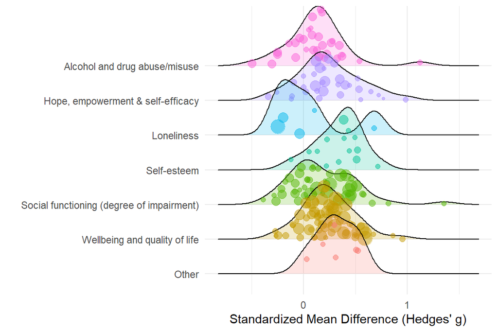

Figure 46: Distribution of effect size estimates, by reintegrational outcomes

```r
analyzed_outcomes <-
  reintegration_dat |>
  mutate(
    # Outcome variables
    outcome_type = case_match(
      analysis_plan,
      c("Employment", "Physical health", "Psychiatric hospitalization") ~ "Other",
      .default = analysis_plan
    ),

    outcome_type = fct_relevel(outcome_type, sort),
    outcome_type = fct_relevel(outcome_type, "Other", after = Inf),
  )


cat_ridge(data = analyzed_outcomes, es = gt_pop, variable = outcome_type, v = vgt_pop)
```

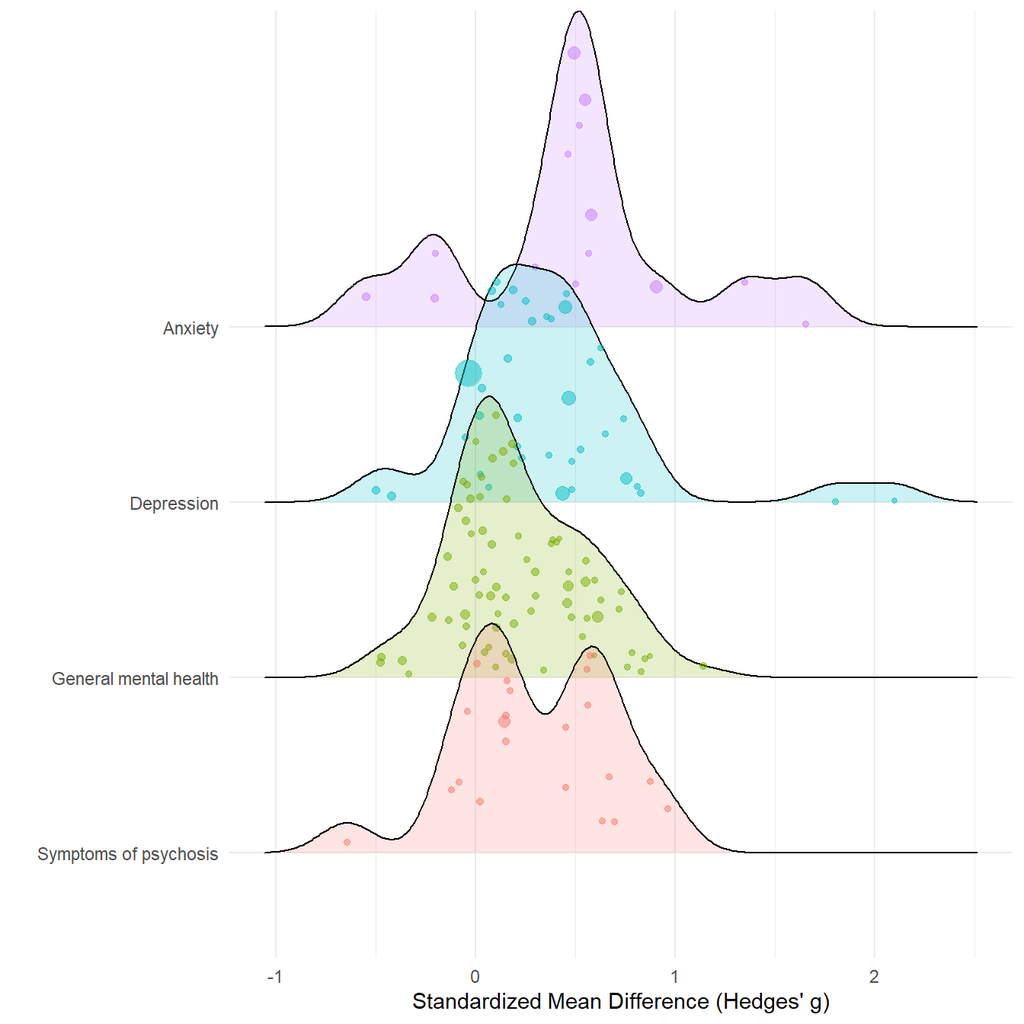

Figure 47: Distribution of effect size estimates, by mental health outcomes.

```r
cat_ridge(data = mental_health_dat, es = gt_pop, variable = analysis_plan, v = vgt_pop)
```

##### Network plot for outcome construct

The following plot shows the network structure of outcomes constructs. Each node represent an outcome construct, the edge between a pair of nodes indicates that there is at least one study that examined the contracts between that pair of constructs The width of the edges indicates the number of studies that compare that pair of constructs. The size of the node corresponds to the number of studies measure that construct.

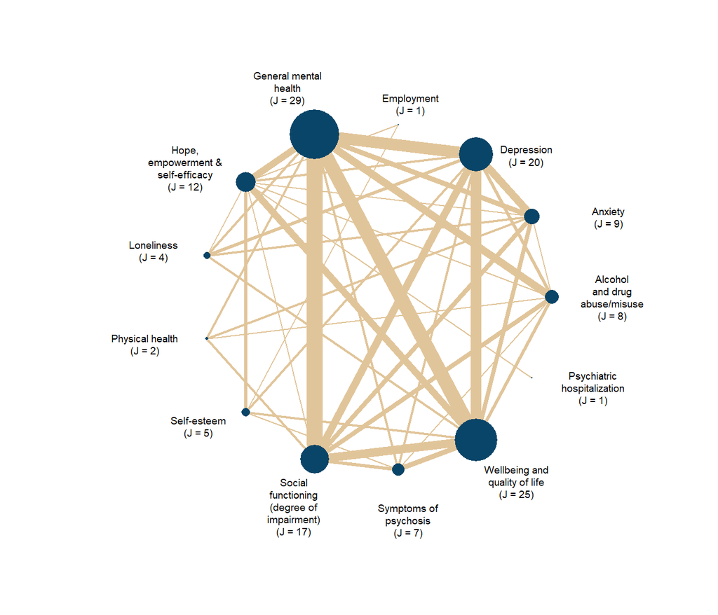

Figure 48: Network structure of contrasts between primary and secondary outcome constructs

```r
gb_dat_reduced <- gb_dat |> select(study, analysis_plan)

res_dat <- gb_dat_reduced |>
  group_by(study) |>
  reframe(var_exp_mirror = unique(analysis_plan))  |>
  full_join(gb_dat_reduced ,
            by = join_by(study),
            relationship = "many-to-many") |>
  group_by(analysis_plan, var_exp_mirror) |>
  reframe(
    m = n_distinct(study),
    k = n()
  ) |>
  mutate(size = m) |>
  select(-m, -k) |>
  arrange(var_exp_mirror) |>
  pivot_wider(names_from = var_exp_mirror, values_from = "size") |>
  arrange(analysis_plan) |>
  as.data.frame()


names(res_dat)[1] <- "level"


edges <- res_dat  |>
  rename(from = "level") |>
  pivot_longer(-from, names_to = "to", values_to = "weight") |>
  filter(from != to, !is.na(weight)) |>
  mutate(
    from_chr = as.character(from),
    to_chr = as.character(to),
    grp_str = paste0(pmin(from_chr, to_chr, na.rm = TRUE), "_", pmax(from_chr, to_chr, na.rm = TRUE))
  ) |>
  distinct(grp_str, .keep_all = TRUE) |>
  select(from, to, weight)

g <- graph_from_data_frame(edges, directed = FALSE)
layout <- layout_in_circle(g)

# Adjust label position outward
label_coords <- layout
label_coords[, 1] <- c(
  label_coords[1, 1] * 1.35, #1.5,
  label_coords[2:6, 1] * 1.5, #1.63,
  label_coords[7, 1] * 1.35, #1.68,
  label_coords[8:13, 1] * 1.4 #1.63
)

label_coords[, 2] <- c(
  label_coords[c(1:3), 2],
  label_coords[4, 2] * 1.13,
  label_coords[5, 2] * 1.3,
  label_coords[6, 2] * 1.13,
  label_coords[c(7:9), 2] * 1.13,
  label_coords[10, 2] * 1.3,
  label_coords[11, 2] * 1.3,
  label_coords[12, 2] * 1.3,
  label_coords[13, 2] * 1.13
)

node_sizes <- diag(as.matrix(res_dat[, -1]))
#node_sizes <- c(8, 9, 20, 1, 29, 12, 4, 2, 5, 17, 7, 25, 1)

#png(filename = "Figures/outcome_network.png", height = 6, width = 6, res = 600, units = "in")
plot(
  g,
  layout = layout,
  edge.width = E(g)$weight,
  edge.color = met.brewer("Navajo")[5],
  vertex.size = node_sizes[c(1:8, 10:13, 9)],
  vertex.label = NA,
  vertex.color = met.brewer("Navajo")[4],
  vertex.frame.width = 0
)

text(
  x = label_coords[, 1],
  y = label_coords[, 2],
  labels = paste0(str_wrap(names(res_dat[c(2:9, 11:14, 10)]), width = 15), "\n(J = ", node_sizes[c(1:8, 10:13, 9)], ")"),
  cex = 0.6,
  col = "black",
  xpd = NA
)
#dev.off()
```

### Diagnosis (schizophrenia vs. rest of the effects)

```r
diagnosis_subgroup_dat_cross <- cat_dat_cross(
  data = reintegration_dat,
  variable = schizophrenia,
  study_id = study
)

diagnosis_subgroup_dat_cross |>
  knitr::kable(
    "html",
    col.names = c(
      "Diagnosis",
      colnames(diagnosis_subgroup_dat_cross)[-1]
    )
  ) |>
  kableExtra::column_spec(1, bold = TRUE) |>
  kableExtra::footnote(
    general = "Values outside the parentheses are number of studies, with the number of samples and effect size estimates shown in the parentheses.",
    general_title = "Note: ",
    footnote_as_chunk = T
  ) |>
  kableExtra::kable_styling(bootstrap_options = c("striped", "condensed"), full_width = T)
```

Table 18: Dependency table for diagnosis (reintegration)

| Diagnosis | Other | Schizophrenia |
| --- | --- | --- |
| Other | 37 (172) | - |
| Schizophrenia | - | 9 (33) |

Note: Values outside the parentheses are number of studies, with the number of samples and effect size estimates shown in the parentheses.

```r
diagnosis_subgroup_dat_cross_mental <- cat_dat_cross(
  data = mental_health_dat,
  variable = schizophrenia,
  study_id = study
)

diagnosis_subgroup_dat_cross_mental |>
  knitr::kable(
    "html",
    col.names = c(
      "Diagnosis",
      colnames(diagnosis_subgroup_dat_cross_mental)[-1]
    )
  ) |>
  kableExtra::column_spec(1, bold = TRUE) |>
  kableExtra::footnote(
    general = "Values outside the parentheses are number of studies, with the number of samples and effect size estimates shown in the parentheses.",
    general_title = "Note: ",
    footnote_as_chunk = T
  ) |>
  kableExtra::kable_styling(bootstrap_options = c("striped", "condensed"), full_width = T)
```

Table 19: Dependency table for diagnosis (mental health)

| Diagnosis | Other | Schizophrenia |
| --- | --- | --- |
| Other | 35 (130) | - |
| Schizophrenia | - | 7 (14) |

Note: Values outside the parentheses are number of studies, with the number of samples and effect size estimates shown in the parentheses.

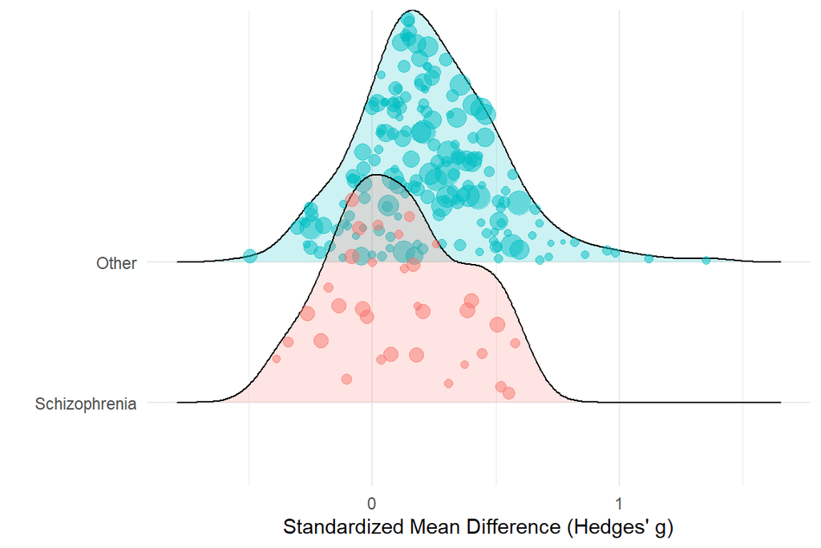

Figure 49: Distribution of effect size estimates, by diagnosis (reintegrational outcome).

```r
cat_ridge(data = reintegration_dat, es = gt_pop, variable = schizophrenia, v = vgt_pop)
```

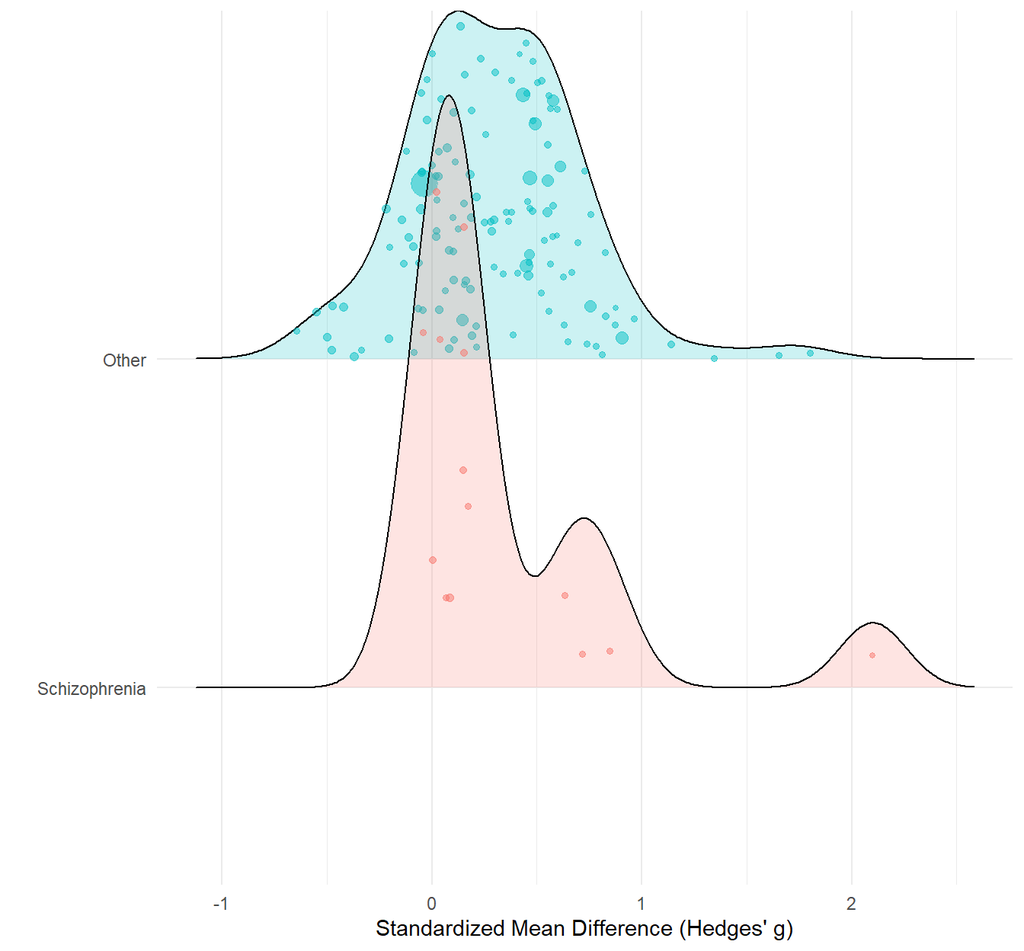

Figure 50: Distribution of effect size estimates, by diagnosis (mental health).

```r
cat_ridge(data = mental_health_dat, es = gt_pop, variable = schizophrenia, v = vgt_pop)
```

### Type of intervention

```r
cbt_subgroup_dat_cross <- cat_dat_cross(
  data = reintegration_dat,
  variable = CBT_int,
  study_id = study
)

cbt_subgroup_dat_cross |>
  knitr::kable(
    "html",
    col.names = c(
      "Intervention",
      colnames(cbt_subgroup_dat_cross)[-1]
    )
  ) |>
  kableExtra::column_spec(1, bold = TRUE) |>
  kableExtra::footnote(
    general = "Values outside the parentheses are number of studies, with the number of samples and effect size estimates shown in the parentheses.",
    general_title = "Note: ",
    footnote_as_chunk = T
  ) |>
  kableExtra::kable_styling(bootstrap_options = c("striped", "condensed"), full_width = T)
```

Table 20: Dependency table for type of intervention (reintegration)

| Intervention | CBT | Other |
| --- | --- | --- |
| CBT | 12 (55) | 1 (5) |
| Other | 1 (5) | 35 (150) |

Note: Values outside the parentheses are number of studies, with the number of samples and effect size estimates shown in the parentheses.

```r
cbt_subgroup_dat_cross_mental <- cat_dat_cross(
  data = mental_health_dat,
  variable = CBT_int,
  study_id = study
)

cbt_subgroup_dat_cross_mental |>
  knitr::kable(
    "html",
    col.names = c(
      "Intervention",
      colnames(cbt_subgroup_dat_cross_mental)[-1]
    )
  ) |>
  kableExtra::column_spec(1, bold = TRUE) |>
  kableExtra::footnote(
    general = "Values outside the parentheses are number of studies, with the number of samples and effect size estimates shown in the parentheses.",
    general_title = "Note: ",
    footnote_as_chunk = T
  ) |>
  kableExtra::kable_styling(bootstrap_options = c("striped", "condensed"), full_width = T)
```

Table 21: Dependency table for type of intervention (mental health)

| Intervention | CBT | Other |
| --- | --- | --- |
| CBT | 12 (49) | 1 (2) |
| Other | 1 (2) | 31 (95) |

Note: Values outside the parentheses are number of studies, with the number of samples and effect size estimates shown in the parentheses.

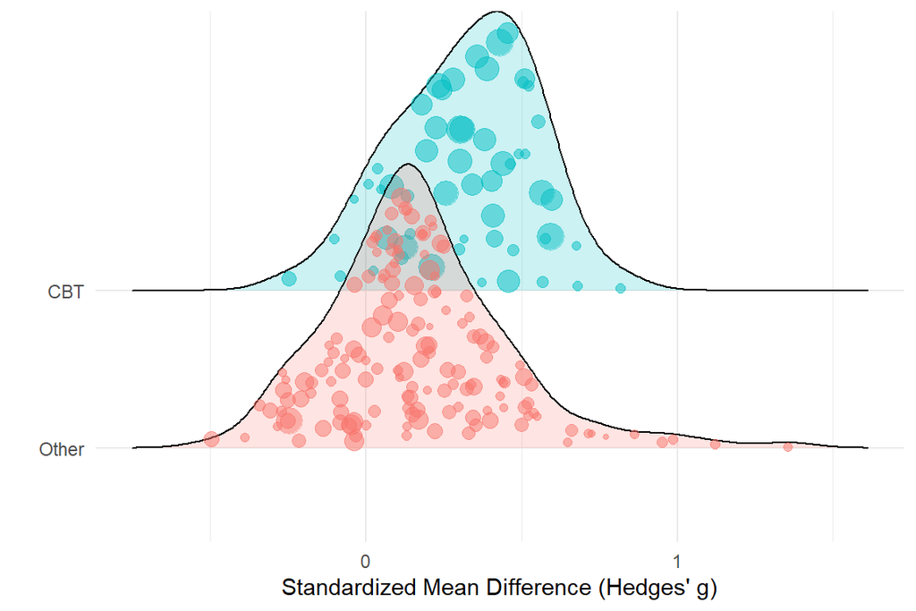

Figure 51: Distribution of effect size estimates, by type of intervention (reintegrational outcome).

```r
cat_ridge(data = reintegration_dat, es = gt_pop, variable = CBT_int, v = vgt_pop)
```

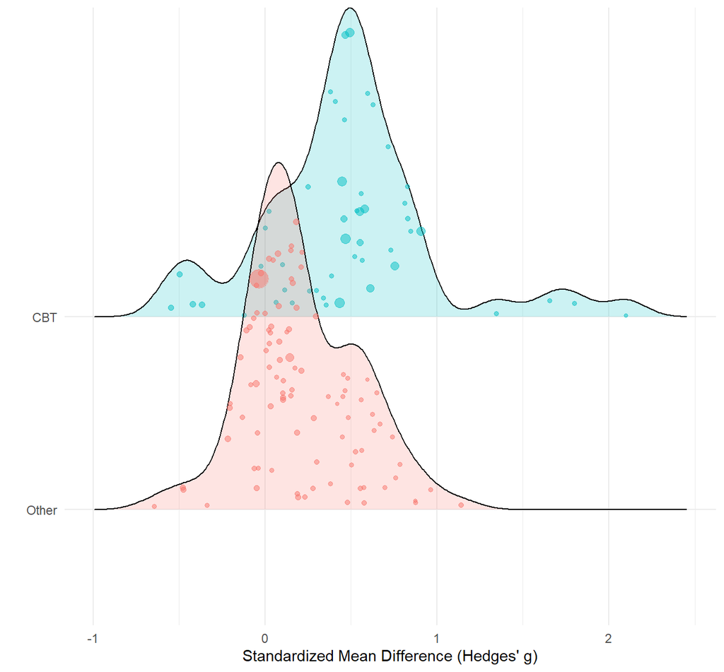

Figure 52: Distribution of effect size estimates, by type of intervention (mental health).

```r
cat_ridge(data = mental_health_dat, es = gt_pop, variable = CBT_int, v = vgt_pop)
```

#### EGM-like plot

**Reintegrational outcomes**

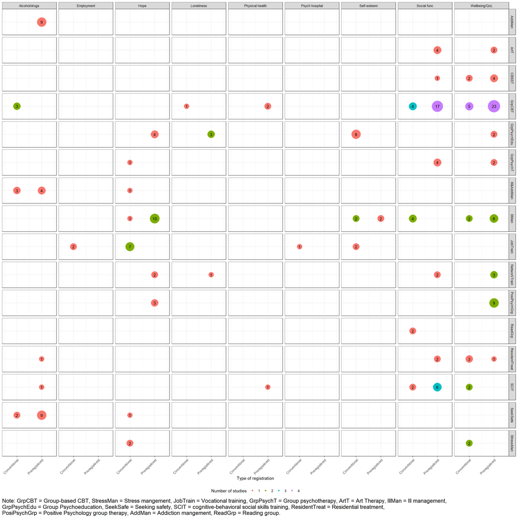

Figure 53: EGM for reintegrational outcomes

```r
egm_dat_reint <-
  reintegration_dat |>
  summarise(
    n = n(),
    n_studies = factor(n_distinct(study), levels = c(1:4)),
    .by = c(trt_group, analysis_plan, prereg_chr)
  ) |>
  mutate(
    n_prereg = case_match(
      prereg_chr,
      "Preregistered" ~ 0.5,
      "Not preregistered" ~ 0
    ),

    constant = "Intervention",

    outcome = case_match(
      analysis_plan,
      "Alcohol and drug abuse/misuse" ~ "Alcohol/drugs",
      "Hope, empowerment & self-efficacy" ~ "Hope",
      "Psychiatric hospitalization" ~ "Psych hospital",
      "Social functioning (degree of impairment)" ~ "Social func",
      "Wellbeing and quality of life" ~ "Wellbeing/QoL",
      .default = analysis_plan
    ),

    intervention = case_match(
      trt_group,
      "group-based CBT" ~ "GrpCBT",
      "stress management" ~ "StressMan",
      "vocational training" ~ "JobTrain",
      "group psychotherapy"  ~ "GrpPsychT",
      "art therapy" ~ "ArtT",
      "illness management" ~ "IllMan",
      "group psychoeducation" ~ "GrpPsychEdu",
      "seeking safety" ~ "SeekSafe",
      "social cognition and interaction training" ~ "SCIT",
      "illness and addiction management" ~ "Ill&AddMan",
      "social network training" ~ "NetworkTrain",
      "cognitive-behavioral social skills training" ~ "CBSST",
      "residential treatment" ~ "ResidentTreat",
      "positive psychology group intervention" ~ "PosiPsychGrp",
      "addiction management" ~ "AddMan",
      "reading group intervention" ~ "ReadGrp"
    )


    #intervention_name = case_match(
    #  intervention,
    #  "Sanctions and economic incentives" ~ "Econ incentives",
    #  "Introduction programmes" ~ "Intro program",
    #  "Combination programmes" ~ "Combi program",
    #  "Language training" ~ "Lang train",
    #  "Labour market training" ~ "Lab market train",
    #  "Job search assistance" ~" Job search ass",
    #  "Subsidized public sector employment" ~ "Sub public emp"
    #),
    #
    #outcome = if_else(outcome == "Duration of social assistance spells", "Dur. social ass spells", outcome)

  )

egm_dat_reint |>
  ggplot(aes(x = n_prereg, y =  constant, size = n, color = n_studies)) +
  geom_point() +
  scale_size(range = c(6, 14)) +
  geom_text(aes(label = n), color = "black", size = 3.5) +
  scale_x_continuous(breaks = seq(0,0.5,0.5), limits = c(0, 1), labels = c("Conventional", "Preregistered")) +
  scale_y_discrete("Interventions") +
  facet_grid(intervention~outcome, scales = "free_y", space = "free_y") +
  theme_bw() +
  theme(
    legend.position = "bottom",
    axis.text.x = element_text(angle = 45, hjust = 1),
    #panel.grid.major = element_blank(),
    #panel.grid.minor = element_blank(),
    #panel.background = element_blank(),
    axis.text.y = element_blank(),
    axis.ticks.y = element_blank(),
    axis.title.y = element_blank(),
    plot.caption = element_text(hjust = 0, size = 14)
  ) +
  coord_cartesian(xlim = c(-0.25, 0.75), ylim = NULL) +
  guides(size = "none") +
  xlab("Type of registration") +
  labs(
    color = "Number of studies",
    caption = paste0(
      "Note: GrpCBT = Group-based CBT, StressMan = Stress mangement, JobTrain = Vocational training, ",
      "GrpPsychT = Group psychotherapy, ArtT = Art Therapy, IllMan = Ill management,\n",
      "GrpPsychEdu = Group Psychoeducation, SeekSafe = Seeking safety, ",
      "SCIT = cognitive-behavioral social skills training, ResidentTreat = Residential treatment,\n",
      "PosiPsychGrp = Positive Psychology group therapy, AddMan = Addiction mangement, ",
      "ReadGrp = Reading group."
    )
  )
```

**Mental health outcomes**

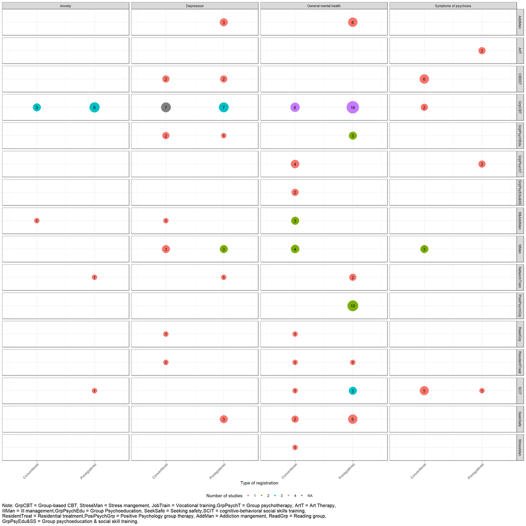

Figure 54: EGM for mental health outcomes

```r
egm_dat_mental <-
  mental_health_dat |>
  summarise(
    n = n(),
    n_studies = factor(n_distinct(study), levels = c(1:4)),
    .by = c(trt_group, analysis_plan, prereg_chr)
  ) |>
  mutate(
    n_prereg = case_match(
      prereg_chr,
      "Preregistered" ~ 0.5,
      "Not preregistered" ~ 0
    ),

    constant = "Intervention",

    outcome = analysis_plan,

    intervention = case_match(
      trt_group,
      "group-based CBT" ~ "GrpCBT",
      "stress management" ~ "StressMan",
      "vocational training" ~ "JobTrain",
      "group psychotherapy"  ~ "GrpPsychT",
      "art therapy" ~ "ArtT",
      "illness management" ~ "IllMan",
      "group psychoeducation" ~ "GrpPsychEdu",
      "seeking safety" ~ "SeekSafe",
      "social cognition and interaction training" ~ "SCIT",
      "illness and addiction management" ~ "Ill&AddMan",
      "social network training" ~ "NetworkTrain",
      "cognitive-behavioral social skills training" ~ "CBSST",
      "residential treatment" ~ "ResidentTreat",
      "positive psychology group intervention" ~ "PosiPsychGrp",
      "addiction management" ~ "AddMan",
      "reading group intervention" ~ "ReadGrp",
      "group psychoeducation & social skill training" ~ "GrpPsyEdu&SS"
    )


    #intervention_name = case_match(
    #  intervention,
    #  "Sanctions and economic incentives" ~ "Econ incentives",
    #  "Introduction programmes" ~ "Intro program",
    #  "Combination programmes" ~ "Combi program",
    #  "Language training" ~ "Lang train",
    #  "Labour market training" ~ "Lab market train",
    #  "Job search assistance" ~" Job search ass",
    #  "Subsidized public sector employment" ~ "Sub public emp"
    #),
    #
    #outcome = if_else(outcome == "Duration of social assistance spells", "Dur. social ass spells", outcome)

  )

egm_dat_mental |>
  ggplot(aes(x = n_prereg, y =  constant, size = n, color = n_studies)) +
  geom_point() +
  scale_size(range = c(6, 14)) +
  geom_text(aes(label = n), color = "black", size = 3.5) +
  scale_x_continuous(breaks = seq(0,0.5,0.5), limits = c(0, 1), labels = c("Conventional", "Preregistered")) +
  scale_y_discrete("Interventions") +
  facet_grid(intervention~outcome, scales = "free_y", space = "free_y") +
  theme_bw() +
  theme(
    legend.position = "bottom",
    axis.text.x = element_text(angle = 45, hjust = 1),
    #panel.grid.major = element_blank(),
    #panel.grid.minor = element_blank(),
    #panel.background = element_blank(),
    axis.text.y = element_blank(),
    axis.ticks.y = element_blank(),
    axis.title.y = element_blank(),
    plot.caption = element_text(hjust = 0, size = 12)
  ) +
  coord_cartesian(xlim = c(-0.25, 0.75), ylim = NULL) +
  guides(size = "none") +
  xlab("Type of registration") +
  labs(
    color = "Number of studies",
    caption = paste0(
      "Note: GrpCBT = Group-based CBT, StressMan = Stress mangement, JobTrain = Vocational training,",
      "GrpPsychT = Group psychotherapy, ArtT = Art Therapy,\nIllMan = Ill management,",
      "GrpPsychEdu = Group Psychoeducation, SeekSafe = Seeking safety,",
      "SCIT = cognitive-behavioral social skills training,\nResidentTreat = Residential treatment,",
      "PosiPsychGrp = Positive Psychology group therapy, AddMan = Addiction mangement, ",
      "ReadGrp = Reading group,\nGrpPsyEdu&SS = Group psychoeducation & social skill training."
    )
  )
```

### Type of test

```r
test_type_dat <-
  reintegration_dat |>
  filter(test_type != "Raw events")

test_type_dat_cross <- cat_dat_cross(
  data = test_type_dat,
  variable = test_type,
  study_id = study
)

test_type_dat_cross |>
  knitr::kable(
    "html",
    col.names = c(
      "Type of test",
      colnames(test_type_dat_cross)[-1]
    )
  ) |>
  kableExtra::column_spec(1, bold = TRUE) |>
  kableExtra::footnote(
    general = "Values outside the parentheses are number of studies, with the number of samples and effect size estimates shown in the parentheses.",
    general_title = "Note: ",
    footnote_as_chunk = T
  ) |>
  kableExtra::kable_styling(bootstrap_options = c("striped", "condensed"), full_width = T)
```

Table 22: Dependency table for type of test (reintegration)

| Type of test | Clinician-rated measure | Self-reported |
| --- | --- | --- |
| Clinician-rated measure | 12 (36) | 5 (8) |
| Self-reported | 5 (8) | 39 (168) |

Note: Values outside the parentheses are number of studies, with the number of samples and effect size estimates shown in the parentheses.

```r
test_type_dat_mental <-
  mental_health_dat |>
  filter(test_type != "Raw events")


test_type_dat_cross_mental <- cat_dat_cross(
  data = test_type_dat_mental,
  variable = test_type,
  study_id = study
)

test_type_dat_cross_mental |>
  knitr::kable(
    "html",
    col.names = c(
      "Type of test",
      colnames(test_type_dat_cross_mental)[-1]
    )
  ) |>
  kableExtra::column_spec(1, bold = TRUE) |>
  kableExtra::footnote(
    general = "Values outside the parentheses are number of studies, with the number of samples and effect size estimates shown in the parentheses.",
    general_title = "Note: ",
    footnote_as_chunk = T
  ) |>
  kableExtra::kable_styling(bootstrap_options = c("striped", "condensed"), full_width = T)
```

Table 23: Dependency table for type of test (mental health)

| Type of test | Clinician-rated measure | Self-reported |
| --- | --- | --- |
| Clinician-rated measure | 14 (41) | 5 (11) |
| Self-reported | 5 (18) | 33 (103) |

Note: Values outside the parentheses are number of studies, with the number of samples and effect size estimates shown in the parentheses.

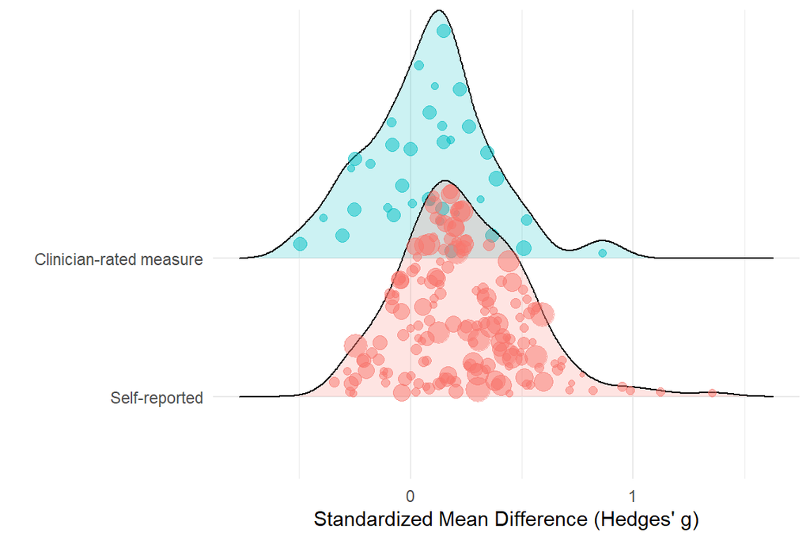

Figure 55: Distribution of effect size estimates, by type of test (reintegrational outcome).

```r
cat_ridge(data = test_type_dat, es = gt_pop, variable = test_type, v = vgt_pop)
```

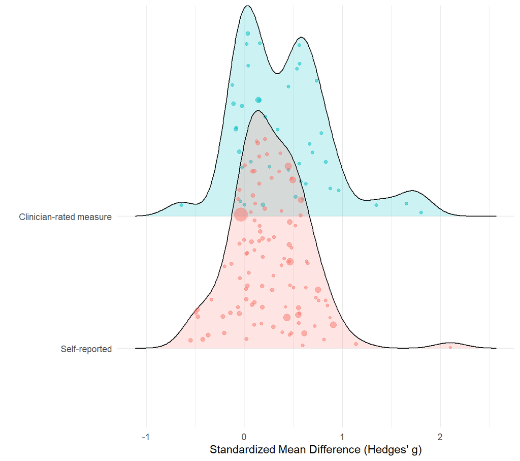

Figure 56: Distribution of effect size estimates, by type of test (mental health).

```r
cat_ridge(data = test_type_dat_mental, es = gt_pop, variable = test_type, v = vgt_pop)
```

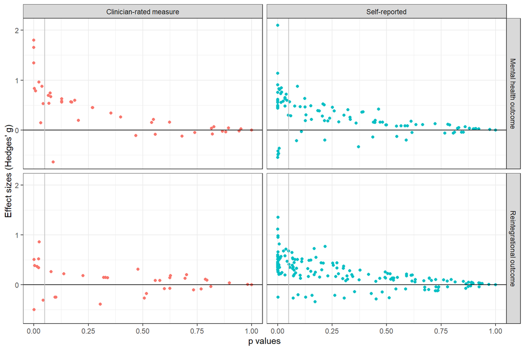

Figure 57: Distributions of effect size by p values and outcome measure type.

```r
test_type_dat_all <-
  gb_dat |>
  filter(test_type != "Raw events") |>
  mutate(
    p_val = 2 * ( 1 - pnorm( abs(gt_pop) / sqrt(vgt_pop) ) ),
  )


ggplot(test_type_dat_all, aes(y = gt_pop, x = p_val, color = test_type)) +
geom_point() +
geom_hline(yintercept = 0) +
geom_vline(xintercept = .05, color = "gray") +
facet_grid(outcome_construct~test_type) +
theme_bw() +
theme(legend.position="none") +
labs(x = "p values", y = "Effect sizes (Hedges' g)")
```

### ITT vs. TOT

```r
strategy_subgroup_dat_cross <- cat_dat_cross(
  data = reintegration_dat,
  variable = analysis_strategy,
  study_id = study
)

strategy_subgroup_dat_cross |>
  knitr::kable(
    "html",
    col.names = c(
      "Strategy",
      colnames(strategy_subgroup_dat_cross)[-1]
    )
  ) |>
  kableExtra::column_spec(1, bold = TRUE) |>
  kableExtra::footnote(
    general = paste0("Values outside the parentheses are number of studies,", "
                     with the number of samples and effect size estimates shown in the parentheses. ",
                     "TOT = treatment on the treated, ITT = Intention to treat."
                     ),
    general_title = "Note: ",
    footnote_as_chunk = T
  ) |>
  kableExtra::kable_styling(bootstrap_options = c("striped", "condensed"), full_width = T)
```

Table 24: Dependency table for estimation strategy (reintegration)

| Strategy | ITT | TOT |
| --- | --- | --- |
| ITT | 22 (108) | - |
| TOT | - | 24 (97) |

Note: Values outside the parentheses are number of studies, with the number of samples and effect size estimates shown in the parentheses. TOT = treatment on the treated, ITT = Intention to treat.

```r
strategy_subgroup_dat_cross_mental <- cat_dat_cross(
  data = mental_health_dat,
  variable = analysis_strategy,
  study_id = study
)

strategy_subgroup_dat_cross_mental |>
  knitr::kable(
    "html",
    col.names = c(
      "Strategy",
      colnames(strategy_subgroup_dat_cross_mental)[-1]
    )
  ) |>
  kableExtra::column_spec(1, bold = TRUE) |>
  kableExtra::footnote(
    general = paste0("Values outside the parentheses are number of studies,", "
                     with the number of samples and effect size estimates shown in the parentheses. ",
                     "TOT = treatment on the treated, ITT = Intention to treat."
                     ),
    general_title = "Note: ",
    footnote_as_chunk = T
  )  |>
  kableExtra::kable_styling(bootstrap_options = c("striped", "condensed"), full_width = T)
```

Table 25: Dependency table for estimation strategy (mental health)

| Strategy | ITT | TOT |
| --- | --- | --- |
| ITT | 18 (69) | - |
| TOT | - | 24 (75) |

Note: Values outside the parentheses are number of studies, with the number of samples and effect size estimates shown in the parentheses. TOT = treatment on the treated, ITT = Intention to treat.

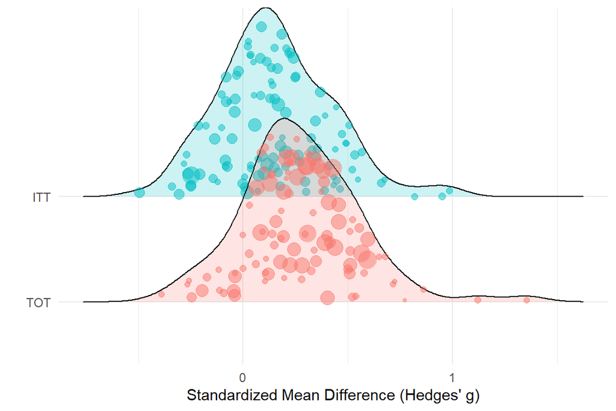

Figure 58: Distribution of effect size estimates, by estiamtion strategy (reintegrational outcome).

```r
cat_ridge(data = reintegration_dat, es = gt_pop, variable = analysis_strategy, v = vgt_pop)
```

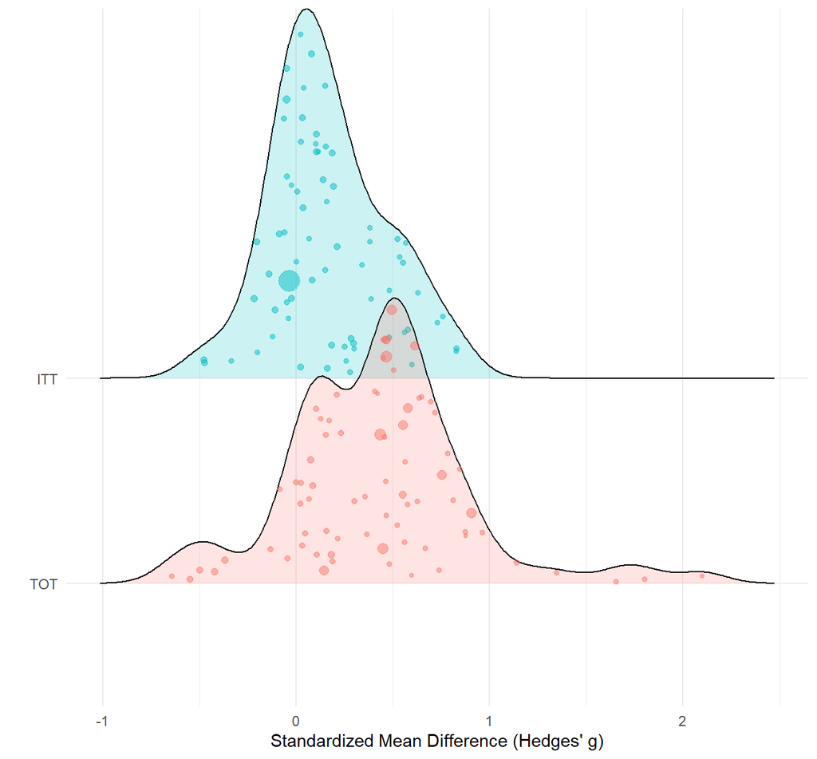

Figure 59: Distribution of effect size estimates, by estiamtion strategy (mental health).

```r
cat_ridge(data = mental_health_dat, es = gt_pop, variable = analysis_strategy, v = vgt_pop)
```

### RCT vs. QES

```r
design_subgroup_dat_cross <- cat_dat_cross(
  data = reintegration_dat,
  variable = QES_design,
  study_id = study
)

design_subgroup_dat_cross |>
  knitr::kable(
    "html",
    col.names = c(
      "Design",
      colnames(design_subgroup_dat_cross)[-1]
    )
  ) |>
  kableExtra::column_spec(1, bold = TRUE) |>
  kableExtra::footnote(
    general = paste0("Values outside the parentheses are number of studies,", "
                     with the number of samples and effect size estimates shown in the parentheses."
                     ),
    general_title = "Note: ",
    footnote_as_chunk = T
  ) |>
  kableExtra::kable_styling(bootstrap_options = c("striped", "condensed"), full_width = T)
```

Table 26: Dependency table for type of research design (reintegration)

| Design | QES | RCT |
| --- | --- | --- |
| QES | 8 (18) | - |
| RCT | - | 38 (187) |

Note: Values outside the parentheses are number of studies, with the number of samples and effect size estimates shown in the parentheses.

```r
design_subgroup_dat_cross_mental <- cat_dat_cross(
  data = mental_health_dat,
  variable = QES_design,
  study_id = study
)

design_subgroup_dat_cross_mental |>
  knitr::kable(
    "html",
    col.names = c(
      "Design",
      colnames(design_subgroup_dat_cross_mental)[-1]
    )
  ) |>
  kableExtra::column_spec(1, bold = TRUE) |>
  kableExtra::footnote(
    general = paste0("Values outside the parentheses are number of studies,", "
                     with the number of samples and effect size estimates shown in the parentheses."
                     ),
    general_title = "Note: ",
    footnote_as_chunk = T
  )  |>
  kableExtra::kable_styling(bootstrap_options = c("striped", "condensed"), full_width = T)
```

Table 27: Dependency table for type of research design (mental health)

| Design | QES | RCT |
| --- | --- | --- |
| QES | 8 (17) | - |
| RCT | - | 34 (127) |

Note: Values outside the parentheses are number of studies, with the number of samples and effect size estimates shown in the parentheses.

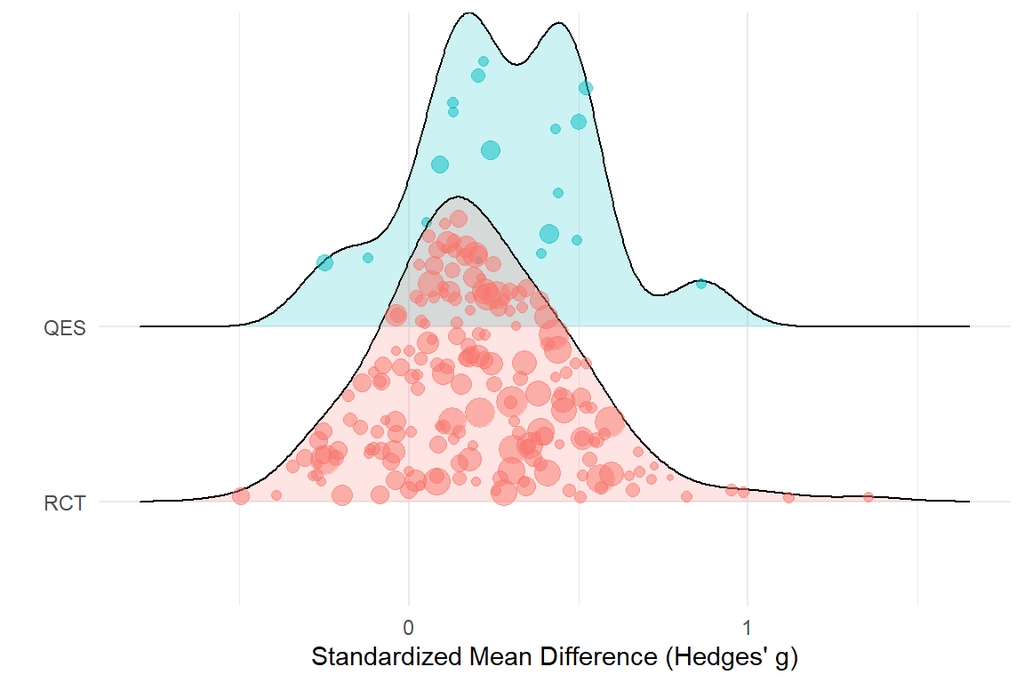

Figure 60: Distribution of effect size estimates, by research design (reintegrational outcome).

```r
cat_ridge(data = reintegration_dat, es = gt_pop, variable = QES_design, v = vgt_pop)
```

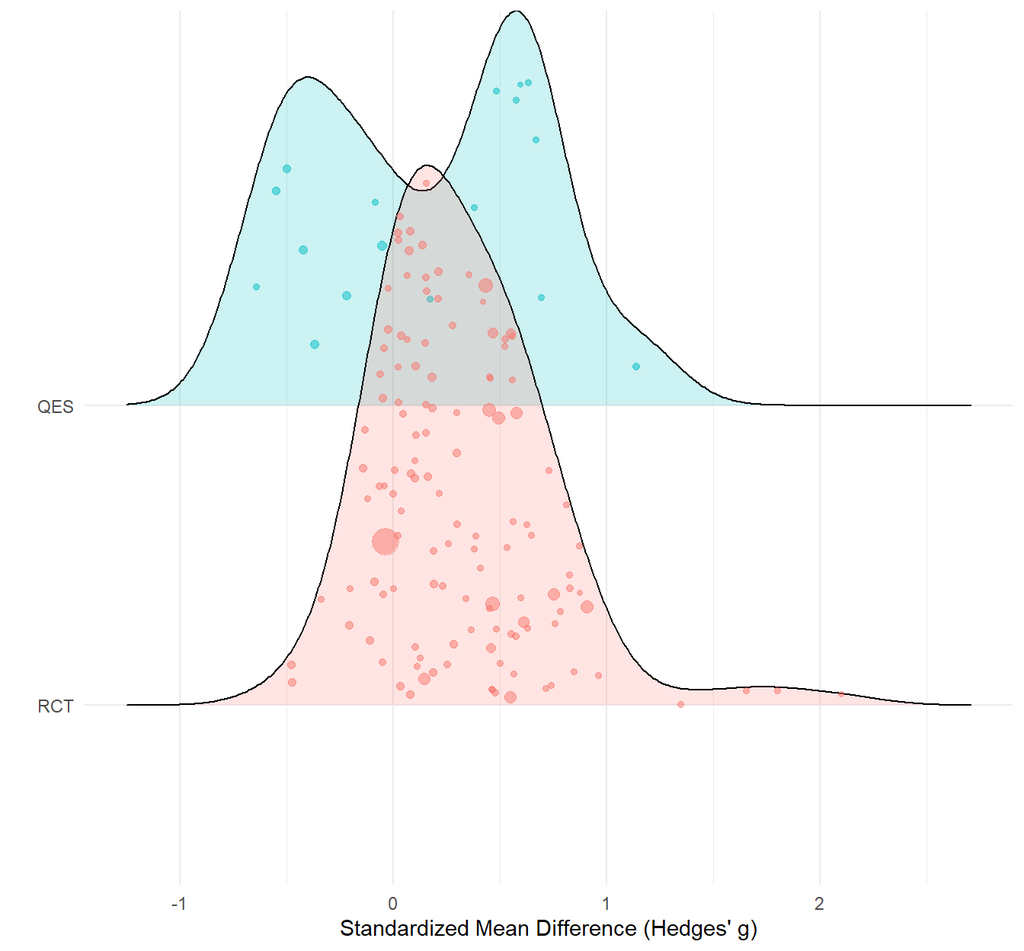

Figure 61: Distribution of effect size estimates, by research design (mental health).

```r
cat_ridge(data = mental_health_dat, es = gt_pop, variable = QES_design, v = vgt_pop)
```

### Type of control

```r
control_subgroup_dat_cross <- cat_dat_cross(
  data = reintegration_dat,
  variable = control,
  study_id = study
)

control_subgroup_dat_cross |>
  knitr::kable(
    "html",
    col.names = c(
      "Control",
      colnames(control_subgroup_dat_cross)[-1]
    )
  ) |>
  kableExtra::column_spec(1, bold = TRUE) |>
  kableExtra::footnote(
    paste0(
      "Values outside the parentheses are number of studies,", "
       with the number of samples and effect size estimates shown in the parentheses."
    ),
    general_title = "Note: ",
    footnote_as_chunk = T
  ) |>
  kableExtra::kable_styling(bootstrap_options = c("striped", "condensed"), full_width = T)
```

Table 28: Dependency table for type of control group (reintegration)

| Control | Individual treatment | TAU | TAU with Waiting-list | Waiting-list only |
| --- | --- | --- | --- | --- |
| Individual treatment | 3 (4) | - | - | - |
| TAU | - | 30 (154) | - | - |
| TAU with Waiting-list | - | - | 9 (34) | - |
| Waiting-list only | - | - | - | 4 (13) |

Note: Values outside the parentheses are number of studies, with the number of samples and effect size estimates shown in the parentheses.

```r
control_subgroup_dat_cross_mental <- cat_dat_cross(
  data = mental_health_dat,
  variable = control,
  study_id = study
)

control_subgroup_dat_cross_mental |>
  knitr::kable(
    "html",
    col.names = c(
      "Control",
      colnames(control_subgroup_dat_cross_mental)[-1]
    )
  ) |>
  kableExtra::column_spec(1, bold = TRUE) |>
  kableExtra::footnote(
    general = "See note in the reintegration table to the left.",
    general_title = "Note: ",
    footnote_as_chunk = T
  )  |>
  kableExtra::kable_styling(bootstrap_options = c("striped", "condensed"), full_width = T)
```

Table 29: Dependency table for type of control group (mental health)

| Control | Individual treatment | TAU | TAU with Waiting-list | Waiting-list only |
| --- | --- | --- | --- | --- |
| Individual treatment | 2 (3) | - | - | - |
| TAU | - | 28 (108) | - | - |
| TAU with Waiting-list | - | - | 9 (26) | - |
| Waiting-list only | - | - | - | 3 (7) |

Note: See note in the reintegration table to the left.

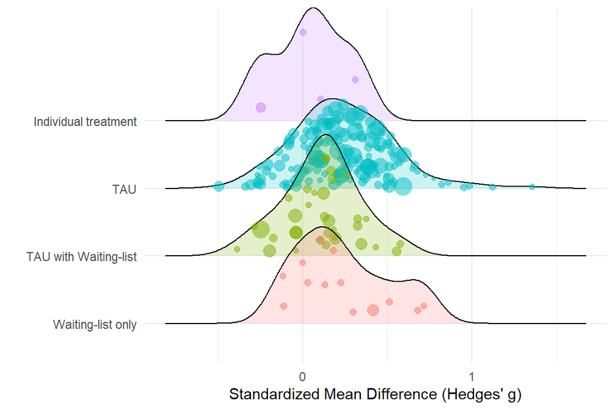

Figure 62: Distribution of effect size estimates, by type of control group (reintegrational outcome).

```r
cat_ridge(data = reintegration_dat, es = gt_pop, variable = control, v = vgt_pop)
```

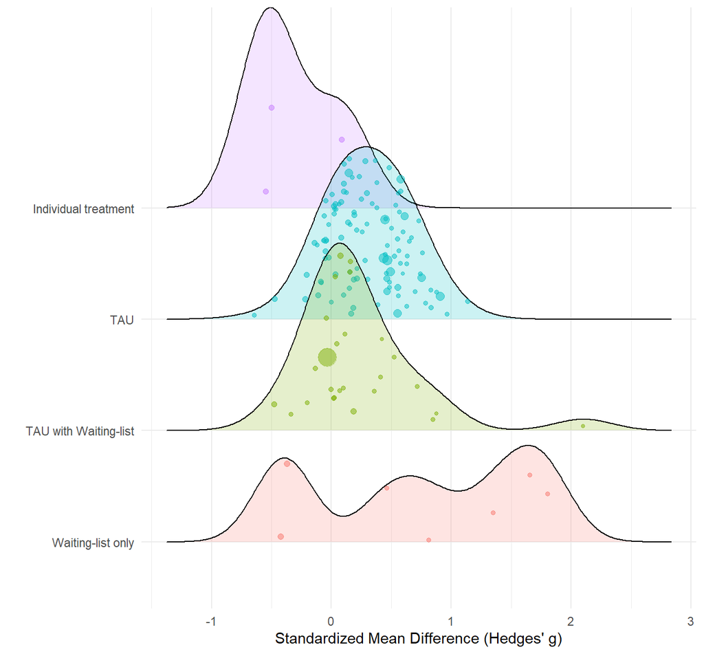

Figure 63: Distribution of effect size estimates, by type of control group (mental health).

```r
cat_ridge(data = mental_health_dat, es = gt_pop, variable = control, v = vgt_pop)
```